# Measles, Bangladesh 2026: descriptive epidemiology of public data

- Show All Code
- Hide All Code
- View Source

Published

October 3, 2026

```r
library(here)
library(dplyr)
library(tidyr)
library(lubridate)
library(ggplot2)
library(ggridges)
library(plotly)
library(sf)
library(slider)
library(knitr)

# visualise-data palette
col_primary <- "#1a1a1a"
col_highlight <- "#c0392b"
col_reference <- "#7f7f7f"
theme_set(
  theme_bw(base_size = 11) +
    theme(panel.grid.minor = element_blank(), legend.position = "bottom")
)
sf_use_s2(FALSE)

# Utility functions
# MMWR epidemiological weeks, Sunday to Saturday, labelled by start date
week_start_of <- function(date) floor_date(date, "week", week_start = 7)
week_label <- function(week) {
  paste0("week ", epiweek(week), " (", fmt_date(week), " to ",
         fmt_date(week + 6), ")")
}
# Sum daily counts by complete epiweek, grouped by the columns in ...
weekly <- function(d, ...) {
  d |>
    mutate(week = week_start_of(date)) |>
    filter(between(week, first_week, last_week)) |>
    group_by(..., week) |>
    summarise(across(c(suspected, confirmed, serum_sent), sum),
              .groups = "drop")
}
fmt <- function(x) format(round(x), big.mark = ",")
fmt_date <- function(d, year = FALSE) {
  paste(day(d), format(d, if (year) "%B %Y" else "%B"))
}
```

```r
# DGHS dashboard series by report date
cases <- read.csv(here("data", "dghs-cases.csv"), na.strings = c("", "NA")) |>
  mutate(date = ymd(date))
cutoff <- max(cases$date)
first_daily <- ymd("2026-04-08")
# First and last complete epiweeks of daily data
first_week <- week_start_of(first_daily - 1) + 7
last_week <- week_start_of(cutoff + 1) - 7

# DGHS district spellings that differ from the OCHA boundaries
district_recode <- c(
  Jhalakathi = "Jhalokati",
  Netrokona = "Netrakona",
  Chapainawabganj = "Chapainababganj"
)
cases <- cases |>
  mutate(district = recode(district, !!!district_recode))

# Boundaries and population (2022 census projection)
adm1 <- st_read(here("data", "covariates", "bgd_adm1.geojson"), quiet = TRUE)
adm2 <- st_read(here("data", "covariates", "bgd_adm2.geojson"), quiet = TRUE)
lookup <- read.csv(here("data", "covariates", "admin_lookup.csv"))

# Divisions west to east by centroid, and districts the same way within each
centroid_lon <- function(g) {
  suppressWarnings(st_coordinates(st_centroid(g))[, 1])
}
division_order <- adm1 |>
  mutate(lon = centroid_lon(geometry)) |>
  arrange(lon) |>
  pull(adm1_name)
district_order <- adm2 |>
  mutate(
    lon = centroid_lon(geometry),
    division = factor(adm1_name, levels = division_order)
  ) |>
  arrange(division, lon) |>
  pull(adm2_name)

pop1 <- read.csv(here("data", "covariates", "population_adm1.csv")) |>
  select(adm1_pcode, pop = t_tl, pop_u5 = t_00_04) |>
  left_join(distinct(lookup, adm1_pcode, division = adm1_name),
            by = "adm1_pcode")
pop2 <- read.csv(here("data", "covariates", "population_adm2.csv")) |>
  select(adm2_pcode, pop = t_tl, pop_u5 = t_00_04) |>
  left_join(select(lookup, adm2_pcode, district = adm2_name,
                   division = adm1_name),
            by = "adm2_pcode")
stopifnot(
  setequal(pop1$division, unique(na.omit(cases$division))),
  setequal(pop2$district, unique(na.omit(cases$district)))
)

# Wide daily series: one row per date and place, one column per measure
widen <- function(d) {
  d |>
    select(-fetched_at, -flag) |>
    pivot_wider(names_from = measure, values_from = value)
}
nat_daily <- cases |>
  filter(level == "national") |>
  widen()
div_daily <- cases |>
  filter(level == "division") |>
  widen() |>
  mutate(division = factor(division, levels = division_order))
dist_daily <- cases |>
  filter(level == "district") |>
  widen() |>
  mutate(district = factor(district, levels = district_order),
         division = factor(division, levels = division_order))
# 15 March to 7 April, loaded onto 7 April as one total
lump <- nat_daily |> filter(date == ymd("2026-04-07")) |> pull(suspected)

# Events marked on time series
events <- read.csv(here("assets", "events.csv")) |>
  mutate(date = ymd(date))
events_marked <- events |>
  filter(!grepl("backfill", event))

# WHO provisional monthly measles and rubella data
who <- read.csv(here("data", "who-monthly.csv")) |>
  mutate(month = make_date(year, month, 1)) |>
  filter(year >= 2023)
stopifnot(all(who$measles_suspect == who$measles_total + who$discarded))
```

**How to read this report**

- Data to 2 October 2026, from the DGHS measles monitoring platform unless stated. Public data only.
- A case is a hospital admission with suspected measles. Counts are admissions, not infections.
- Time is the date a count was reported, a surrogate for onset.
- Place is the district of the reporting facility, not of residence.
- Weeks are MMWR epidemiological weeks, Sunday to Saturday. Weekly plots show complete weeks only, from week 15 (12 April to 18 April) to week 38 (20 September to 26 September).

**Data and definitions**

Measles outbreak data sourced from the DGHS measles monitoring dashboard (measles.dghs.gov.bd), except where otherwise noted. Population numbers are from the 2022 census projection.

## Data reporting process

Cases are reported as number of measles admissions to medical facilities, collated by district civil surgeon offices, with daily counts submitted to the DGHS dashboard. Lab testing data and day of week effects in reporting are in Appendix 2.

```r
n_districts <- lookup |> count(division = adm1_name, name = "districts")
modal <- function(x) as.integer(names(which.max(table(x))))
reports <- div_daily |>
  filter(date >= first_daily) |>
  select(date, division, report_count) |>
  group_by(division) |>
  mutate(expected = modal(report_count)) |>
  ungroup() |>
  left_join(n_districts, by = "division") |>
  mutate(value = if_else(division == "Dhaka", report_count,
                         report_count / expected))
p <- ggplot(reports, aes(date, value)) +
  geom_line(colour = col_primary) +
  facet_wrap(~division, ncol = 4, scales = "free_y") +
  scale_x_date(date_labels = "%b") +
  labs(x = "Report date", y = "Reports / expected (Dhaka: count)")
ggplotly(p)
```

[interactive chart not shown]

Figure 1: Reporting units submitting per day, by division, Bangladesh, 8 April 2026 to cutoff. Divisions other than Dhaka: reports as a proportion of the most frequent daily count. Dhaka: count of reports. Source: DGHS measles monitoring platform.

```r
reports |>
  distinct(division, districts, expected) |>
  kable(caption = "Districts and most frequent daily count of reports, by division")
```

Districts and most frequent daily count of reports, by division

| division | districts | expected |
| --- | --- | --- |
| Barishal | 6 | 6 |
| Chattogram | 11 | 11 |
| Dhaka | 13 | 43 |
| Khulna | 10 | 10 |
| Mymensingh | 4 | 4 |
| Rajshahi | 8 | 9 |
| Rangpur | 8 | 8 |
| Sylhet | 4 | 4 |

### Source data definitions

```r
tibble::tribble(
  ~measure, ~dashboard_label, ~notes,
  "suspected", "suspected24h", "Hospital admissions with suspected measles; inclusion of confirmed unknown",
  "confirmed", "confirmed24h", "Laboratory method not stated",
  "suspected_deaths", "suspectedDeath24h", "Inclusion of confirmed deaths, and place of death, unknown",
  "confirmed_deaths", "confirmedDeath24h", "As above",
  "admitted", "admitted24h", "Relation to suspected not published",
  "discharged", "discharged24h", "\"Recovered\" in the dashboard's Excel export",
  "serum_sent", "serumSent24h", "Serum samples sent to the laboratory; not in the Excel export"
) |>
  kable()
```

Table 1: DGHS dashboard indicators, reported as 24-hour counts by report date

| measure | dashboard_label | notes |
| --- | --- | --- |
| suspected | suspected24h | Hospital admissions with suspected measles; inclusion of confirmed unknown |
| confirmed | confirmed24h | Laboratory method not stated |
| suspected_deaths | suspectedDeath24h | Inclusion of confirmed deaths, and place of death, unknown |
| confirmed_deaths | confirmedDeath24h | As above |
| admitted | admitted24h | Relation to suspected not published |
| discharged | discharged24h | “Recovered” in the dashboard’s Excel export |
| serum_sent | serumSent24h | Serum samples sent to the laboratory; not in the Excel export |

### WHO standard case definition

```r
read.csv(here("assets", "case-definitions.csv")) |>
  select(classification, definition, page) |>
  kable()
```

Table 2: WHO measles surveillance case definitions, used in WHO monthly data (verbatim)

| classification | definition | page |
| --- | --- | --- |
| Suspected | A suspected case is one in which a patient with fever and maculopapular (non-vesicular) rash, or in whom a health-care worker suspects measles. | 5 |
| Laboratory-confirmed | Laboratory-confirmed measles: A suspected case of measles that has been confirmed positive by testing in a proficient laboratory, and vaccine-associated illness has been ruled out (see the section bel… | 5 |
| Epidemiologically linked | Epidemiologically linked measles: A suspected case of measles that has not been confirmed by a laboratory, but was geographically and temporally related with dates of rash onset occurring 7–23 days ap… | 5 |
| Clinically compatible | Clinically compatible measles: A suspected case with fever and maculopapular (non-vesicular) rash and at least one of cough, coryza or conjunctivitis, but no adequate clinical specimen was taken and t… | 5 |
| Non-measles discarded | Non-measles discarded case: A suspected case that has been investigated and discarded as a non-measles (and non-rubella) when any of the following are true: » negative laboratory testing in a proficie… | 6 |
| Total measles cases (counting rule) | Note about counting measles cases: total measles cases are usually the sum of laboratory-confirmed cases, epidemiologically linked cases and clinically compatible cases. | 22 |

# Situation update

```r
cum <- nat_daily |>
  summarise(across(c(suspected, confirmed, suspected_deaths,
                     confirmed_deaths), sum))
nat_weekly <- weekly(nat_daily) |>
  mutate(per_100k = 1e5 * suspected / sum(pop1$pop))
this_week <- nat_weekly |> filter(week == last_week)
prev_week <- nat_weekly |> filter(week == last_week - 7)
change_pct <- 100 * (this_week$suspected / prev_week$suspected - 1)
div_last <- weekly(div_daily, division) |>
  filter(week == last_week) |>
  left_join(pop1, by = "division") |>
  mutate(per_100k = 1e5 * suspected / pop) |>
  arrange(desc(per_100k))
dist_last <- weekly(dist_daily, district) |>
  filter(week == last_week)
partial <- nat_daily |> filter(date > last_week + 6)
partial_text <- if (nrow(partial) == 0) {
  "none; the latest week is complete"
} else {
  paste0(fmt(sum(partial$suspected)), " suspected cases in ", nrow(partial),
         " days (", fmt_date(min(partial$date)), " to ",
         fmt_date(cutoff), ")")
}
```

- Cumulative, 15 March to 2 October: 194,084 suspected and 21,623 confirmed cases; 1,012 suspected and 102 confirmed deaths, as published.
- Latest complete week 38 (20 September to 26 September): 8,147 suspected cases, +1% on the week before; 4.9 per 100,000 population (Figure 3).
- Highest division incidence that week: Barishal, 10.6 per 100,000. Districts reporting any suspected case that week: 61 of 64.
- Current week to date: 7,271 suspected cases in 6 days (27 September to 2 October).

**Interpreting these data**

# Epidemic curve

Outbreak surveillance data appears from 15 March. The DGHS report a single cumulative total from 15 March through 7 April (10,878 suspected cases), followed by daily incident data from 8 April to present. It is likely the outbreak started substantially earlier, perhaps as early as December 2025 among the Rohingya population in Cox’s Bazar.

**Latest daily data**

```r
tail(nat_daily) |> kable(caption = "Daily DGHS measles dashboard data")
```

Daily DGHS measles dashboard data

| date | level | division | district | report_count | admitted | confirmed | confirmed_deaths | discharged | serum_sent | suspected | suspected_deaths |
| --- | --- | --- | --- | --- | --- | --- | --- | --- | --- | --- | --- |
| 2026-09-27 | national | NA | NA | 92 | 1155 | 113 | 0 | 943 | 407 | 1228 | 9 |
| 2026-09-28 | national | NA | NA | 93 | 1159 | 96 | 0 | 1186 | 431 | 1214 | 3 |
| 2026-09-29 | national | NA | NA | 94 | 1186 | 84 | 0 | 1093 | 482 | 1255 | 5 |
| 2026-09-30 | national | NA | NA | 95 | 1145 | 128 | 0 | 1075 | 472 | 1221 | 4 |
| 2026-10-01 | national | NA | NA | 93 | 1077 | 82 | 0 | 1100 | 367 | 1132 | 2 |
| 2026-10-02 | national | NA | NA | 82 | 1144 | 21 | 1 | 2960 | 275 | 1221 | 3 |

```r
p <- nat_weekly |>
  mutate(text = paste0(week_label(week), ": ", fmt(suspected),
                       " suspected, ", fmt(confirmed), " confirmed")) |>
  ggplot(aes(week + 3.5)) +
  geom_col(aes(y = suspected, fill = "Suspected", text = text), width = 7) +
  geom_line(aes(y = confirmed, colour = "Confirmed")) +
  geom_point(aes(y = confirmed, colour = "Confirmed", text = text),
             size = 1) +
  geom_vline(data = filter(events_marked, date >= first_week),
             aes(xintercept = date), colour = col_primary,
             linetype = "dotted") +
  scale_fill_manual(values = c(Suspected = col_reference)) +
  scale_colour_manual(values = c(Confirmed = col_highlight)) +
  scale_x_date(date_labels = "%b") +
  labs(x = "Week (Sunday to Saturday)", y = "Cases per week",
       fill = NULL, colour = NULL)
ggplotly(p, tooltip = "text")
```

[interactive chart not shown]

Figure 3: Suspected (bars) and confirmed (line) measles cases per epidemiological week, Bangladesh, complete weeks from 12 April 2026 to the latest complete week. Confirmed cases are overlaid, not stacked: whether suspected includes confirmed is not published. Dotted lines: nationwide campaign (20 April); camp campaign and platform launch (26 April). Cases from 15 March to 7 April, reported as one total, are not shown. Source: DGHS measles monitoring platform, report date.

## Epidemic timespans

```r
tibble::tribble(
  ~interval, ~public_data, ~line_list_variable, ~other_source,
  "Generation or serial interval", "No", "No (no transmission pairs)", "Literature",
  "Exposure to onset (incubation)", "No", "No", "Literature",
  "Fever to rash", "No", "Yes", "",
  "Rash to notification", "No", "Yes", "",
  "Notification to investigation", "No", "Yes", "",
  "Rash to specimen; specimen to result", "No", "Yes", "",
  "Onset to admission", "No", "Yes", "",
  "Admission to report date", "No; indirect signs only (days with missing reports)", "No", "",
  "Suspected to confirmed", "No (share tested varies)", "Yes", "",
  "Admission to exit (discharge or death)", "Partly: deconvolution of discharges and deaths against admissions, if deaths are hospital deaths", "Yes", "",
  "Onset to death", "No", "Free-text Comment only", "Unknown",
  "Campaign dose to rash", "No", "DateLastMCV", "",
  "Undetected period (first infection to detection)", "No", "Onset dates before April", "Molecular clock on sequences"
) |>
  kable(col.names = c("Interval", "Public data", "Line list variable",
                      "Other source"))
```

Table 3: Relevant epidemiological time intervals and potential data sources

| Interval | Public data | Line list variable | Other source |
| --- | --- | --- | --- |
| Generation or serial interval | No | No (no transmission pairs) | Literature |
| Exposure to onset (incubation) | No | No | Literature |
| Fever to rash | No | Yes |  |
| Rash to notification | No | Yes |  |
| Notification to investigation | No | Yes |  |
| Rash to specimen; specimen to result | No | Yes |  |
| Onset to admission | No | Yes |  |
| Admission to report date | No; indirect signs only (days with missing reports) | No |  |
| Suspected to confirmed | No (share tested varies) | Yes |  |
| Admission to exit (discharge or death) | Partly: deconvolution of discharges and deaths against admissions, if deaths are hospital deaths | Yes |  |
| Onset to death | No | Free-text Comment only | Unknown |
| Campaign dose to rash | No | DateLastMCV |  |
| Undetected period (first infection to detection) | No | Onset dates before April | Molecular clock on sequences |

# Spatial spread

```r
district_cum <- dist_daily |>
  group_by(district) |>
  summarise(suspected = sum(suspected), .groups = "drop") |>
  left_join(pop2, by = "district") |>
  mutate(per_100k = 1e5 * suspected / pop)
stopifnot(nrow(district_cum) == 64, !anyNA(district_cum$pop))

map_districts <- adm2 |>
  left_join(district_cum, by = c("adm2_name" = "district"))
breaks_100k <- c(0, 25, 50, 100, 200, 400)
stopifnot(!anyNA(map_districts$per_100k),
          max(map_districts$per_100k) <= max(breaks_100k))
```

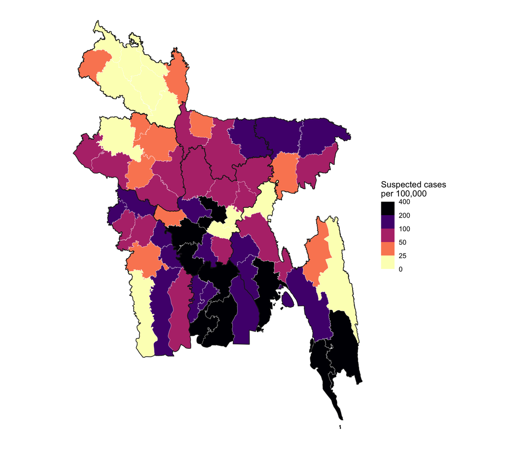

Figure 4: Cumulative suspected measles cases per 100,000 population, by district of reporting facility, Bangladesh, 15 March 2026 to cutoff. Sources: DGHS measles monitoring platform; 2022 census projection.

```r
ggplot() +
  geom_sf(data = map_districts, aes(fill = per_100k), colour = "white",
          linewidth = 0.1) +
  geom_sf(data = adm1, fill = NA, colour = col_primary, linewidth = 0.4) +
  scale_fill_viridis_b(breaks = breaks_100k, limits = range(breaks_100k),
                       option = "magma", direction = -1,
                       show.limits = TRUE) +
  labs(fill = "Suspected cases\nper 100,000") +
  theme_void() +
  theme(legend.position = "right")
```

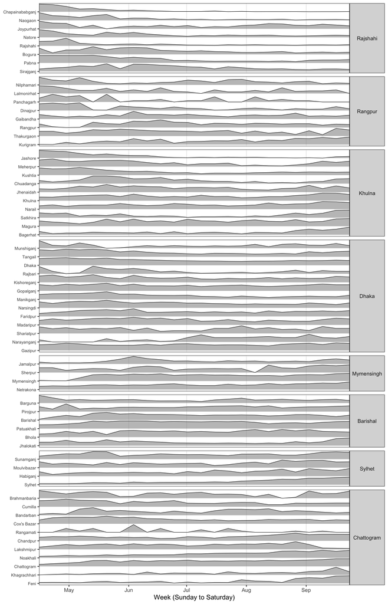

Figure 5: Weekly suspected measles cases as a share of each district’s peak week, by district of reporting facility and division, Bangladesh, complete weeks from 12 April 2026 to the latest complete week. Districts ordered within each division by week of peak, earliest at top. Heights show timing, not size: each district is scaled to its own peak. A peak in the first or last week may lie outside the series. Source: DGHS measles monitoring platform, report date.

```r
dist_weekly <- weekly(dist_daily, division, district) |>
  group_by(district) |>
  mutate(peak_week = week[which.max(suspected)]) |>
  ungroup()
# Latest peak first, so the earliest peak is the top row
ridge_order <- dist_weekly |>
  distinct(district, peak_week) |>
  arrange(desc(peak_week), desc(as.integer(district))) |>
  pull(district) |>
  as.character()

dist_weekly |>
  group_by(district) |>
  mutate(share_of_peak = suspected / max(suspected)) |>
  ungroup() |>
  ggplot(aes(week + 3.5, factor(district, levels = ridge_order),
             height = share_of_peak)) +
  geom_ridgeline(scale = 0.9, fill = col_reference, alpha = 0.5,
                 colour = col_primary, linewidth = 0.3) +
  facet_grid(division ~ ., scales = "free_y", space = "free_y") +
  scale_x_date(date_labels = "%b", expand = c(0, 0)) +
  # Room above the top ridge in each panel
  scale_y_discrete(expand = expansion(add = c(0.2, 1))) +
  labs(x = "Week (Sunday to Saturday)", y = NULL) +
  theme(axis.text.y = element_text(size = 7),
        panel.grid.major.y = element_blank(),
        strip.text.y = element_text(angle = 0))
```

# Vaccination

```r
events |>
  filter(grepl("campaign", event, ignore.case = TRUE)) |>
  transmute(date = fmt_date(date, year = TRUE), event, scope, source) |>
  kable(col.names = c("Date", "Event", "Scope", "Source"))
```

Table 4: Measles-rubella vaccination campaign rounds, Bangladesh, 2026

| Date | Event | Scope | Source |
| --- | --- | --- | --- |
| 5 April 2026 | MR campaign starts in high-risk upazilas | national | KS review note 2026-10-02 (primary source to cite) |
| 20 April 2026 | MR campaign nationwide | national | KS review note 2026-10-02 (primary source to cite) |
| 26 April 2026 | MR campaign in Rohingya camps starts | camps | https://www.who.int/bangladesh/news/detail/19-05-2026-mass-vaccination-campaign-protects-more-than-166-000-children-from-measles-in-rohingya-refugee-camps |

Not yet in the data: dates of the May round and the September mop-up, and coverage by division (`sitrep/data/dghs-campaign.csv`, not built).

# Appendix 1: subpopulation outbreaks

## Rohingya population

```r
# TODO properly review reports from rohingya population to identify outbreak events in a consistent dataframe
```

# Appendix 2: Test positivity and data reporting pipeline

## Lab testing

Serum samples are recorded on the platform from May. Serum sent per suspected case and confirmed per suspected case are ratios of totals since 1 May. Neither is test positivity: the platform does not report negative results, and a confirmation need not come from a sample recorded on the platform.

```r
serum_start <- ymd("2026-05-01")
sum_testing <- function(d) {
  d |>
    filter(date >= serum_start) |>
    summarise(across(c(suspected, serum_sent, confirmed), sum))
}
bind_rows(
  div_daily |>
    group_by(place = as.character(division)) |>
    sum_testing(),
  nat_daily |>
    sum_testing() |>
    mutate(place = "National")
) |>
  mutate(serum_per_suspected = serum_sent / suspected,
         confirmed_per_suspected = confirmed / suspected) |>
  kable(digits = 2, format.args = list(big.mark = ","),
        col.names = c("Place", "Suspected", "Serum sent", "Confirmed",
                      "Serum sent per suspected",
                      "Confirmed per suspected"))
```

Table 5: Suspected cases, serum samples sent and confirmed cases, by division, Bangladesh, 1 May 2026 to cutoff. Source: DGHS measles monitoring platform, report date.

| Place | Suspected | Serum sent | Confirmed | Serum sent per suspected | Confirmed per suspected |
| --- | --- | --- | --- | --- | --- |
| Barishal | 18,507 | 3,909 | 716 | 0.21 | 0.04 |
| Chattogram | 33,721 | 8,654 | 2,774 | 0.26 | 0.08 |
| Dhaka | 65,096 | 20,963 | 10,002 | 0.32 | 0.15 |
| Khulna | 10,068 | 2,876 | 402 | 0.29 | 0.04 |
| Mymensingh | 7,946 | 3,153 | 636 | 0.40 | 0.08 |
| Rajshahi | 6,378 | 1,358 | 436 | 0.21 | 0.07 |
| Rangpur | 2,459 | 2,207 | 548 | 0.90 | 0.22 |
| Sylhet | 14,348 | 9,546 | 962 | 0.67 | 0.07 |
| National | 158,523 | 52,666 | 16,476 | 0.33 | 0.10 |

WHO monthly surveillance records discarded cases, so it gives the only laboratory positivity in public data. Share tested = (laboratory-confirmed + discarded) / suspected; an upper bound, since cases can be discarded without a test (Table 2). Laboratory positivity = laboratory-confirmed / (laboratory-confirmed + discarded).

```r
who |>
  filter(year == 2026) |>
  transmute(
    month = format(month, "%B"),
    suspected = measles_suspect,
    lab_confirmed = measles_lab_confirmed,
    epi_linked = measles_epi_linked,
    clinical = measles_clinical,
    discarded,
    share_tested = (measles_lab_confirmed + discarded) / measles_suspect,
    positivity = measles_lab_confirmed / (measles_lab_confirmed + discarded)
  ) |>
  kable(digits = 2, format.args = list(big.mark = ","),
        col.names = c("Month", "Suspected", "Lab-confirmed", "Epi-linked",
                      "Clinically compatible", "Discarded", "Share tested",
                      "Lab positivity"))
```

Table 6: Measles cases by final classification, share tested and laboratory positivity, by month, Bangladesh, 2026. Source: WHO provisional monthly measles and rubella data.

| Month | Suspected | Lab-confirmed | Epi-linked | Clinically compatible | Discarded | Share tested | Lab positivity |
| --- | --- | --- | --- | --- | --- | --- | --- |
| January | 490 | 79 | 5 | 0 | 406 | 0.99 | 0.16 |
| February | 979 | 239 | 95 | 2 | 643 | 0.90 | 0.27 |
| March | 7,387 | 1,640 | 2,867 | 4 | 2,876 | 0.61 | 0.36 |
| April | 27,198 | 5,128 | 15,779 | 24 | 6,267 | 0.42 | 0.45 |
| May | 24,126 | 4,866 | 16,093 | 18 | 3,149 | 0.33 | 0.61 |
| June | 13,140 | 4,489 | 5,873 | 0 | 2,778 | 0.55 | 0.62 |
| July | 7,148 | 4,445 | 788 | 1 | 1,914 | 0.89 | 0.70 |
| August | 2,604 | 1,678 | 14 | 0 | 912 | 0.99 | 0.65 |

## Day of week reporting

```r
weekday <- div_daily |>
  filter(date >= first_daily) |>
  arrange(division, date) |>
  group_by(division) |>
  mutate(centred = slide_dbl(suspected, mean, .before = 3, .after = 3,
                             .complete = TRUE),
         rel = suspected / centred) |>
  ungroup() |>
  filter(!is.na(rel)) |>
  mutate(weekday = wday(date, label = TRUE, week_start = 6)) |>
  group_by(division, weekday) |>
  summarise(cell = sprintf("%.2f (%.2f to %.2f)", median(rel),
                           quantile(rel, 0.25), quantile(rel, 0.75)),
            .groups = "drop") |>
  pivot_wider(names_from = weekday, values_from = cell)
kable(weekday)
```

Table 7: Daily suspected cases relative to the centred 7-day mean, by weekday and division: median (interquartile range), Bangladesh, 8 April 2026 to cutoff. Source: DGHS measles monitoring platform, report date.

| division | Sat | Sun | Mon | Tue | Wed | Thu | Fri |
| --- | --- | --- | --- | --- | --- | --- | --- |
| Rajshahi | 0.69 (0.57 to 0.79) | 1.05 (0.96 to 1.21) | 1.09 (1.05 to 1.19) | 1.01 (0.94 to 1.14) | 1.00 (0.93 to 1.15) | 0.98 (0.81 to 1.13) | 1.03 (0.97 to 1.19) |
| Rangpur | 0.54 (0.41 to 0.80) | 1.24 (0.89 to 1.38) | 1.19 (1.00 to 1.57) | 0.89 (0.76 to 1.04) | 0.94 (0.81 to 1.32) | 1.04 (0.86 to 1.27) | 0.82 (0.71 to 1.10) |
| Khulna | 0.64 (0.48 to 0.74) | 1.08 (0.96 to 1.17) | 1.14 (1.04 to 1.20) | 1.09 (0.99 to 1.19) | 1.05 (0.95 to 1.11) | 1.00 (0.88 to 1.14) | 0.99 (0.87 to 1.18) |
| Dhaka | 0.82 (0.80 to 0.87) | 1.07 (1.04 to 1.11) | 1.05 (1.01 to 1.08) | 0.99 (0.95 to 1.03) | 1.04 (0.97 to 1.10) | 0.98 (0.93 to 1.04) | 1.05 (0.99 to 1.09) |
| Mymensingh | 0.76 (0.59 to 0.85) | 1.18 (0.96 to 1.35) | 1.02 (0.95 to 1.20) | 1.07 (0.91 to 1.17) | 0.94 (0.78 to 1.06) | 1.06 (0.94 to 1.26) | 0.91 (0.77 to 1.16) |
| Barishal | 0.80 (0.68 to 0.90) | 1.10 (1.04 to 1.20) | 1.03 (0.92 to 1.12) | 1.00 (0.94 to 1.11) | 1.04 (0.97 to 1.20) | 1.00 (0.89 to 1.06) | 1.02 (0.89 to 1.11) |
| Sylhet | 0.75 (0.58 to 0.86) | 1.11 (0.93 to 1.23) | 1.04 (0.95 to 1.15) | 1.04 (0.79 to 1.22) | 1.00 (0.92 to 1.16) | 1.03 (0.93 to 1.16) | 1.01 (0.91 to 1.09) |
| Chattogram | 0.85 (0.73 to 0.95) | 1.04 (0.95 to 1.06) | 1.09 (1.05 to 1.14) | 1.01 (0.96 to 1.08) | 0.99 (0.93 to 1.06) | 1.01 (0.93 to 1.17) | 1.01 (0.96 to 1.07) |

# Appendix 3: data validation

## Comparison with WHO

WHO still produce monthly measles and rubella surveillance data, but with an apparent change in case ascertainment from June.

```r
who_2026 <- who |>
  filter(year(month) == 2026) |>
  select(month, `WHO suspected` = measles_suspect,
         `WHO total (lab + epi-linked + clinical)` = measles_total) |>
  pivot_longer(-month, names_to = "series", values_to = "cases")
dghs_monthly <- nat_daily |>
  filter(date >= first_daily) |>
  group_by(month = floor_date(date, "month")) |>
  summarise(cases = sum(suspected), days = n(), .groups = "drop") |>
  # Current month dropped while incomplete; April starts on 8 April
  filter(month < floor_date(cutoff + 1, "month")) |>
  mutate(series = "DGHS suspected (hospital)")

p <- ggplot() +
  geom_col(data = who_2026,
           aes(month, cases, fill = series),
           position = position_dodge(width = 25), width = 24) +
  geom_point(data = dghs_monthly,
             aes(month, cases, colour = series, text = paste(days, "days")),
             size = 2.5) +
  geom_vline(xintercept = ymd("2026-06-01"), linetype = "dotted",
             colour = col_reference) +
  annotate("text", x = ymd("2026-06-01"), y = max(dghs_monthly$cases),
           label = "WHO classification change", hjust = -0.05,
           size = 3, colour = col_reference) +
  scale_fill_manual(values = c(
    `WHO suspected` = "#d4d4d4",
    `WHO total (lab + epi-linked + clinical)` = col_reference)) +
  scale_colour_manual(values = c(`DGHS suspected (hospital)` = col_highlight)) +
  scale_x_date(date_labels = "%b") +
  labs(x = NULL, y = "Cases per month", fill = NULL, colour = NULL)
ggplotly(p, tooltip = c("x", "y", "text"))
```

[interactive chart not shown]

Figure 6: Measles cases per month: WHO surveillance suspected and total cases (bars), and DGHS hospital suspected cases (points), Bangladesh, January 2026 to cutoff. DGHS April is 8 to 30 April; 15 March to 7 April is reported as one total; the current month is shown when complete. Sources: WHO provisional monthly measles and rubella data; DGHS measles monitoring platform.

## Data quality

```r
checks <- read.csv(here("data", "dghs-cases-checks.csv"))
failed <- checks |>
  filter(!pass) |>
  transmute(item = check, date, division, measure,
            detail = paste("expected", expected, "observed", observed))
flagged <- cases |>
  filter(!is.na(flag), level == "national", measure == "suspected") |>
  transmute(item = flag, date = as.character(date), division = NA,
            measure = NA, detail = paste("national suspected", value))
bind_rows(failed, flagged) |> kable()
```

Table 8: Failed checks and flagged dates, DGHS dashboard series, Bangladesh, 2026

| item | date | division | measure | detail |
| --- | --- | --- | --- | --- |
| no_negative_values | 2026-04-18 | Barishal | confirmed_deaths | expected 0 observed -2 |
| prelaunch_empty | 2026-04-02 | NA | NA | national suspected 0 |
| prelaunch_empty | 2026-04-03 | NA | NA | national suspected 0 |
| prelaunch_empty | 2026-04-04 | NA | NA | national suspected 0 |
| prelaunch_empty | 2026-04-05 | NA | NA | national suspected 0 |
| prelaunch_backfill | 2026-04-07 | NA | NA | national suspected 10878 |

```r
read.csv(here("sitrep", "data", "dghs-source-compare.csv")) |>
  mutate(month = format(ymd(date), "%Y-%m")) |>
  filter(!is.na(diff)) |>
  group_by(month) |>
  summarise(comparisons = n(), differ = sum(diff != 0),
            net_difference = sum(diff)) |>
  kable()
```

Table 9: Agreement of dashboard and press release counts by month, Bangladesh, 2026

| month | comparisons | differ | net_difference |
| --- | --- | --- | --- |
| 2026-04 | 1328 | 149 | 34570 |
| 2026-05 | 1674 | 52 | -3842 |
| 2026-06 | 1620 | 0 | 0 |
| 2026-07 | 1512 | 0 | 0 |
| 2026-08 | 1566 | 6 | 44 |
| 2026-09 | 1242 | 0 | 0 |